# 07. 시계열

#### 가법모형 시계열 분해

```r
de_data_add = decompose(ts_KOSPI_C, type = "additive")
str(de_data_add)
```

```
## List of 6
##  $ x       : Time-Series [1:5232] from 1 to 15.3: 521 521 558 581 587 ...
##  $ seasonal: Time-Series [1:5232] from 1 to 15.3: -8.49 -9.31 1.25 11.91 4.82 ...
##  $ trend   : Time-Series [1:5232] from 1 to 15.3: NA NA NA NA NA NA NA NA NA NA ...
##  $ random  : Time-Series [1:5232] from 1 to 15.3: NA NA NA NA NA NA NA NA NA NA ...
##  $ figure  : num [1:365] -8.49 -9.31 1.25 11.91 4.82 ...
##  $ type    : chr "additive"
##  - attr(*, "class")= chr "decomposed.ts"
```

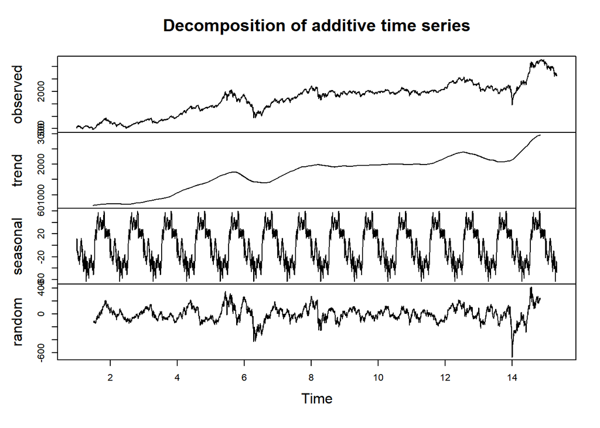

```r
plot(de_data_add)
```

#### 승법 모형 시계열 분해

```r
de_data_multi = decompose(ts_KOSPI_C, type = "multiplicative")
str(de_data_multi)
```

```
## List of 6
##  $ x       : Time-Series [1:5232] from 1 to 15.3: 521 521 558 581 587 ...
##  $ seasonal: Time-Series [1:5232] from 1 to 15.3: 1 1 1.01 1.02 1.01 ...
##  $ trend   : Time-Series [1:5232] from 1 to 15.3: NA NA NA NA NA NA NA NA NA NA ...
##  $ random  : Time-Series [1:5232] from 1 to 15.3: NA NA NA NA NA NA NA NA NA NA ...
##  $ figure  : num [1:365] 1 1 1.01 1.02 1.01 ...
##  $ type    : chr "multiplicative"
##  - attr(*, "class")= chr "decomposed.ts"
```

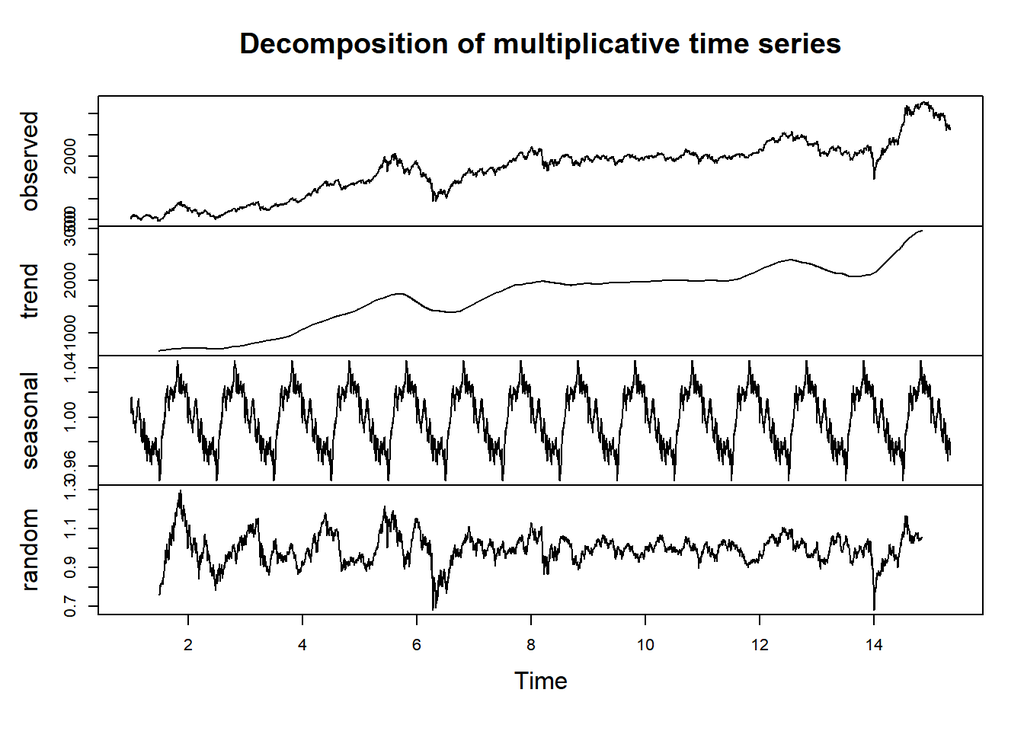

```r
plot(de_data_multi)
```

#### 시계열 회귀 모형 만들기

#### 시계열 데이터 y = B0 + B1(추세요인) + B2(계절성 요인) + e

```r
KOSPI = getSymbols("^KS11",
                   from = "2020-01-01",
                   to = "2022-03-13",
                   auto.assign = FALSE)
```

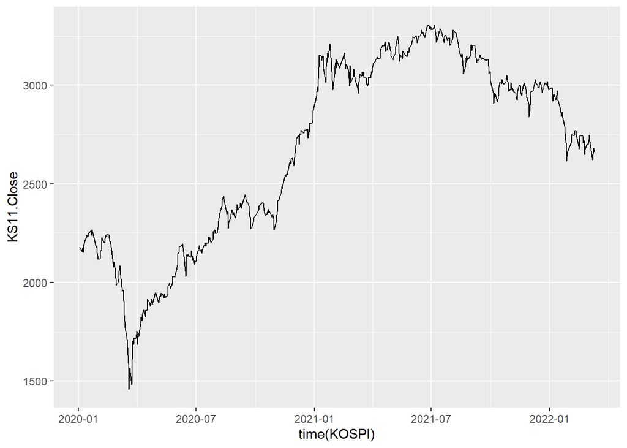

```r
ggplot(KOSPI, aes(x = time(KOSPI), y = KS11.Close)) +
  geom_line()
```

```r
# ts데이터 변환
library(forecast)
ts_data = ts(data = as.numeric(KOSPI$KS11.Close),
             frequency = 5) # 1년을 5일 간격
# frequency : 계절성이 반복되는 주기
```

#### 추세를 독립 변수로 활용한 시계열 회귀 모형

```r
fit_lm = tslm(ts_data ~ trend)
summary(fit_lm)
```

```
##
## Call:
## tslm(formula = ts_data ~ trend)
##
## Residuals:
##    Min     1Q Median     3Q    Max
## -697.3 -184.0  -44.7  277.4  550.0
##
## Coefficients:
##              Estimate Std. Error t value Pr(>|t|)
## (Intercept) 2.022e+03  2.485e+01   81.38   <2e-16 ***
## trend       2.412e+00  7.959e-02   30.30   <2e-16 ***
## ---
## Signif. codes:  0 '***' 0.001 '**' 0.01 '*' 0.05 '.' 0.1 ' ' 1
##
## Residual standard error: 288.3 on 538 degrees of freedom
## Multiple R-squared:  0.6305, Adjusted R-squared:  0.6298
## F-statistic:   918 on 1 and 538 DF,  p-value: < 2.2e-16
```

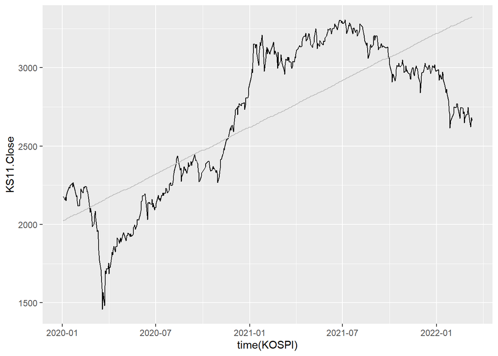

```r
ggplot(KOSPI, aes(x = time(KOSPI), y = KS11.Close)) +
  geom_line() +
  geom_line(y = fit_lm$fitted.values, color = "grey")
```

```r
pred = data.frame(forecast(fit_lm, h = 20),  # 20일동안의 예측
                  stringsAsFactors = FALSE)
head(pred)
```

```
##        Point.Forecast    Lo.80    Hi.80    Lo.95    Hi.95
## 109.00       3326.938 2955.618 3698.258 2758.471 3895.405
## 109.20       3329.350 2958.022 3700.678 2760.871 3897.828
## 109.40       3331.761 2960.426 3703.097 2763.271 3900.251
## 109.60       3334.173 2962.830 3705.516 2765.671 3902.675
## 109.80       3336.584 2965.233 3707.935 2768.070 3905.098
## 110.00       3338.996 2967.637 3710.354 2770.470 3907.521
```

```r
pred$Point.Forecast # 20일동안의 예측값
```

```
##  [1] 3326.938 3329.350 3331.761 3334.173 3336.584 3338.996 3341.407 3343.819
##  [9] 3346.230 3348.642 3351.054 3353.465 3355.877 3358.288 3360.700 3363.111
## [17] 3365.523 3367.934 3370.346 3372.757
```

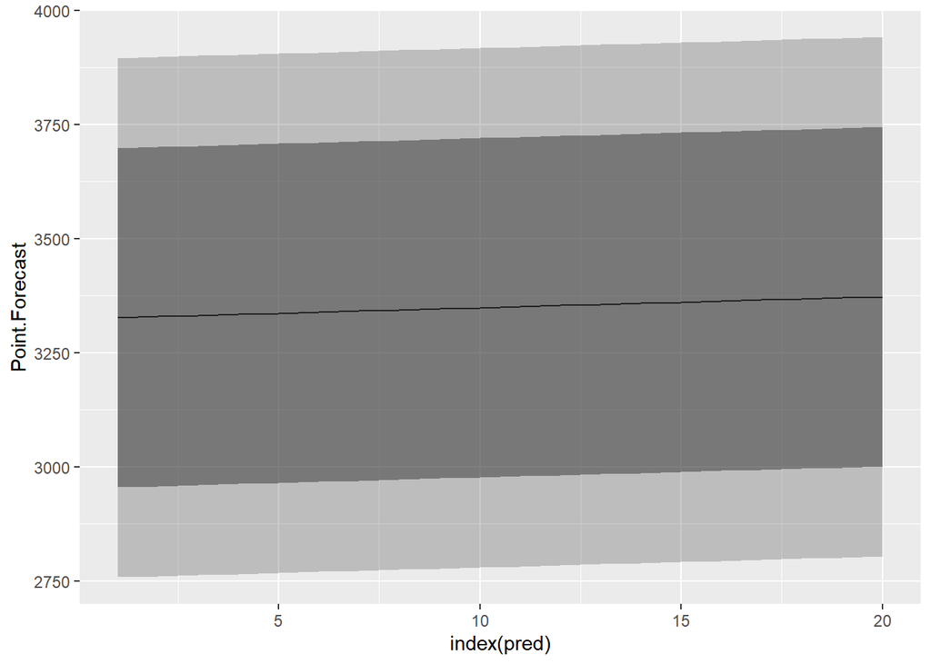

```r
ggplot(pred, aes(x = index(pred), y = Point.Forecast)) +
  geom_line() +
  geom_ribbon(aes(ymin = Lo.95, ymax = Hi.95), alpha = 0.25) +
  geom_ribbon(aes(ymin = Lo.80, ymax = Hi.80), alpha = 0.5)
```

#### 계절성 요인 반영

```r
ts_data = ts(data = as.numeric(KOSPI$KS11.Close),
             frequency = 12)  # 계절성의 주기 = 12 (월별 간격)
```

```r
fitted = tslm(ts_data ~ trend + season)
summary(fitted)
```

```
##
## Call:
## tslm(formula = ts_data ~ trend + season)
##
## Residuals:
##     Min      1Q  Median      3Q     Max
## -700.23 -181.93  -45.52  275.66  545.01
##
## Coefficients:
##              Estimate Std. Error t value Pr(>|t|)
## (Intercept) 2043.1396    48.3508  42.257   <2e-16 ***
## trend          2.4118     0.0804  29.999   <2e-16 ***
## season2       -8.9456    61.3822  -0.146    0.884
## season3      -23.6098    61.3824  -0.385    0.701
## season4      -34.8369    61.3827  -0.568    0.571
## season5      -30.4912    61.3830  -0.497    0.620
## season6      -27.3123    61.3835  -0.445    0.657
## season7      -23.9374    61.3841  -0.390    0.697
## season8      -28.8677    61.3848  -0.470    0.638
## season9      -18.8088    61.3856  -0.306    0.759
## season10     -18.0515    61.3865  -0.294    0.769
## season11     -20.2431    61.3875  -0.330    0.742
## season12     -15.8695    61.3886  -0.259    0.796
## ---
## Signif. codes:  0 '***' 0.001 '**' 0.01 '*' 0.05 '.' 0.1 ' ' 1
##
## Residual standard error: 291.2 on 527 degrees of freedom
## Multiple R-squared:  0.6309, Adjusted R-squared:  0.6225
## F-statistic: 75.06 on 12 and 527 DF,  p-value: < 2.2e-16
```

#### 추세와 계절성 요인을 독립변수로 활용한 시계열 회귀 모형 적합

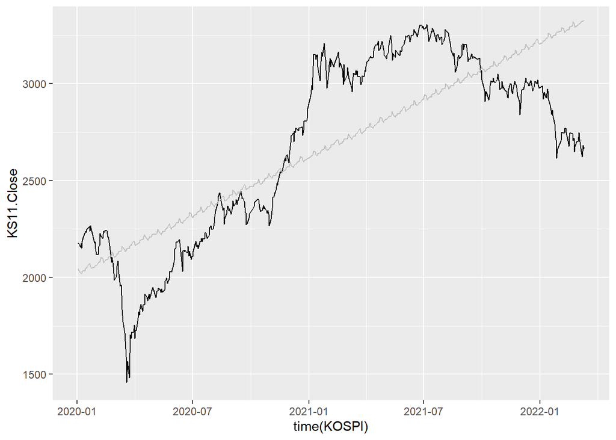

```r
ggplot(KOSPI, aes(x = time(KOSPI), y = KS11.Close)) +
  geom_line() +
  geom_line(y = fitted$fitted.values, color = "grey")
```

#### 가변수 활용

```r
ts_data = ts(data = as.numeric(KOSPI$KS11.Close),
             frequency = 20)
t = time(ts_data) ; head(t)
```

```
## Time Series:
## Start = c(1, 1)
## End = c(1, 6)
## Frequency = 20
## [1] 1.00 1.05 1.10 1.15 1.20 1.25
```

```r
t.break = data.frame(t, ts_data) ; head(t.break)
```

```
##      t ts_data
## 1 1.00 2175.17
## 2 1.05 2176.46
## 3 1.10 2155.07
## 4 1.15 2175.54
## 5 1.20 2151.31
## 6 1.25 2186.45
```

```r
t.break[t.break$t < 3.65,] = 0
t.break[t.break$t > 3.75,] = 0
tb1 = ts(t.break$t, frequency = 20)
```

```r
fit.t = tslm(ts_data ~ t)
AIC(fit.t)
```

```
## [1] 7653.64
```

```r
fit.tb = tslm(ts_data ~ t + I(t^2) + I(t^3) + I(tb1^3))
AIC(fit.tb)
```

```
## [1] 6773.982
```

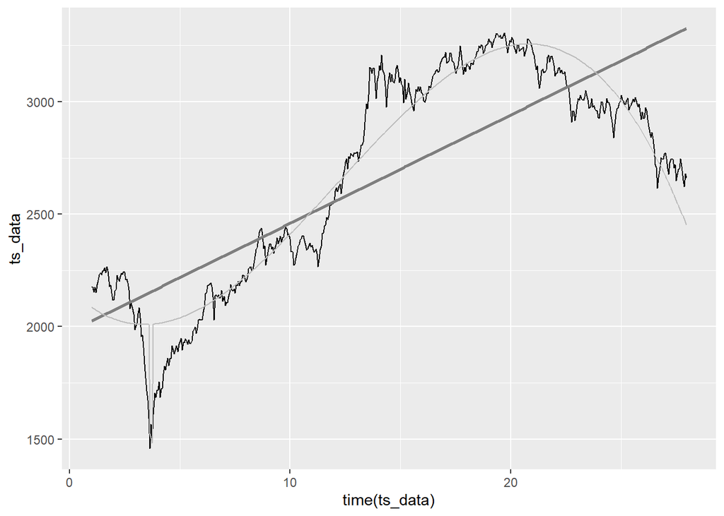

```r
ggplot(ts_data, aes(x = time(ts_data))) +
  geom_line(aes(y = ts_data)) +
  geom_line(aes(y = fit.t$fitted.values),
            color = "#7f7f7f", size = 1) +
  geom_line(aes(y = fit.tb$fitted.values),
            color = "#bcbcbc")
```

```r
new = data.frame(t = t[length(t)] + seq(1, by = 0.05, length.out = 20))
forecast(fit.t, newdata = new)
```

```
##       Point Forecast    Lo 80    Hi 80    Lo 95    Hi 95
## 28.00       3372.757 3001.288 3744.227 2804.062 3941.453
## 28.05       3375.169 3003.691 3746.647 2806.461 3943.877
## 28.10       3377.580 3006.094 3749.066 2808.860 3946.301
## 28.15       3379.992 3008.498 3751.486 2811.259 3948.725
## 28.20       3382.404 3010.901 3753.906 2813.658 3951.149
## 28.25       3384.815 3013.304 3756.326 2816.057 3953.573
## 28.30       3387.227 3015.708 3758.746 2818.456 3955.998
## 28.35       3389.638 3018.111 3761.165 2820.854 3958.422
## 28.40       3392.050 3020.514 3763.585 2823.253 3960.846
## 28.45       3394.461 3022.917 3766.005 2825.652 3963.271
## 28.50       3396.873 3025.320 3768.425 2828.051 3965.695
## 28.55       3399.284 3027.724 3770.845 2830.449 3968.119
## 28.60       3401.696 3030.127 3773.265 2832.848 3970.544
## 28.65       3404.107 3032.530 3775.685 2835.246 3972.968
## 28.70       3406.519 3034.933 3778.105 2837.645 3975.393
## 28.75       3408.930 3037.336 3780.525 2840.043 3977.818
## 28.80       3411.342 3039.739 3782.945 2842.442 3980.242
## 28.85       3413.754 3042.142 3785.365 2844.840 3982.667
## 28.90       3416.165 3044.545 3787.786 2847.239 3985.092
## 28.95       3418.577 3046.947 3790.206 2849.637 3987.516
```

#### auto.arima를 이용하여 KOSPI 지수 예측하기

##### 정상성과 차분

- 정상성은 시간의 흐름에 영향X
- 계절성이나 추세가 있는 시계열은 정상X
- 정상성이 있는 시계열의 경우에는 시간에 따라 평평하게 변화, 일정한 분산

##### 차분 : 정상성이 없는 시계열에 정상성을 나타냄

- 로그변환과 같이 시계열의 분산에 대한 변화를 일정하게 유지
- 정상성이 나타나는 시계열은 ACF가 0으로 빠르게 감소

#### 단위근 검정을 통해 차분을 할지, 얼마나 할지 결정

#### 단위근 검정

```r
library(urca)
```

```r
KOSPI = getSymbols("^KS11",
                   from = "2020-01-01",
                   to = "2022-03-01",
                   auto.assign = FALSE)
ts_kospi = ts(as.numeric(KOSPI$KS11.Close), frequency = 20)
```

```r
ur_test = ur.kpss(ts_kospi)
summary(ur_test)
```

```
##
## #######################
## # KPSS Unit Root Test #
## #######################
##
## Test is of type: mu with 6 lags.
##
## Value of test-statistic is: 5.9559
##
## Critical value for a significance level of:
##                 10pct  5pct 2.5pct  1pct
## critical values 0.347 0.463  0.574 0.739
```

#### 1차 차분

```r
dif_1 = diff(ts_kospi, differences = 1)
ur_test2 = ur.kpss(dif_1)
summary(ur_test2)
```

```
##
## #######################
## # KPSS Unit Root Test #
## #######################
##
## Test is of type: mu with 6 lags.
##
## Value of test-statistic is: 0.2887
##
## Critical value for a significance level of:
##                 10pct  5pct 2.5pct  1pct
## critical values 0.347 0.463  0.574 0.739
```

#### 로그 변환 이후 2차 차분

```r
dif_2 = diff(log(ts_kospi), differences = 2)
ur_test3 = ur.kpss(dif_2)
summary(ur_test3)
```

```
##
## #######################
## # KPSS Unit Root Test #
## #######################
##
## Test is of type: mu with 6 lags.
##
## Value of test-statistic is: 0.0074
##
## Critical value for a significance level of:
##                 10pct  5pct 2.5pct  1pct
## critical values 0.347 0.463  0.574 0.739
```

- 통계량 < 0.05

#### auto.arima

- 잔차는 모형의 적합성을 판단하는 역할
- 시계열 모형을 만들고 난 후 잔차를 확인했을 때, 자기상관이 없고 잔차의 평균은 0
- 만약 자기상관이 있을경우 => 잔차에 아직도 정보가 남아있음
- 잔차의 평균이 0이 아닐 경우 예측값이 한쪽으로 편향

```r
(fit = auto.arima(ts_kospi))
```

```
## Series: ts_kospi
## ARIMA(0,1,0)
##
## sigma^2 = 1112:  log likelihood = -2620.59
## AIC=5243.18   AICc=5243.19   BIC=5247.46
```

##### 적합한 모형의 자기상관이 있는지 판단

##### Ljung-Box 검정 (귀무가설 : 모형에 자기상관이 없다)

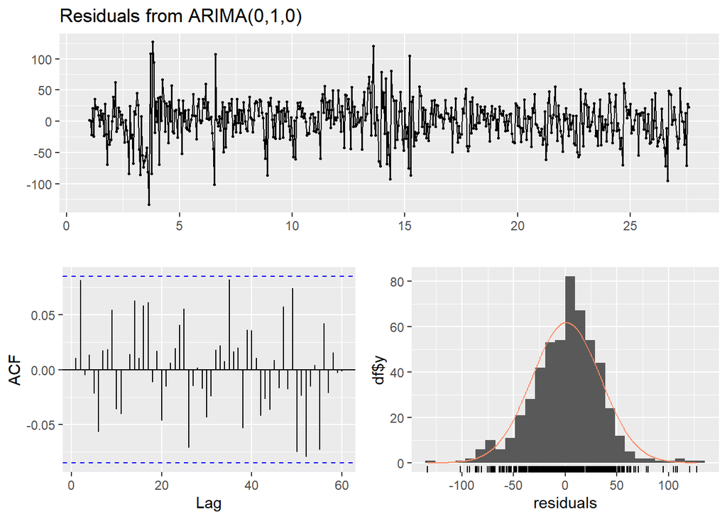

```
##
##  Ljung-Box test
##
## data:  Residuals from ARIMA(0,1,0)
## Q* = 32.511, df = 40, p-value = 0.794
##
## Model df: 0.   Total lags used: 40
```

```r
checkresiduals(fit)
```

- 귀무가설 기각X
- 특정범위 내에서 ACF값이 변화
- 다가올 5일 예측

```r
(fore = data.frame(forecast(fit, h = 5)))
```

```
##       Point.Forecast    Lo.80    Hi.80    Lo.95    Hi.95
## 27.65        2699.18 2656.443 2741.917 2633.820 2764.540
## 27.70        2699.18 2638.741 2759.619 2606.747 2791.613
## 27.75        2699.18 2625.158 2773.202 2585.973 2812.387
## 27.80        2699.18 2613.706 2784.654 2568.459 2829.901
## 27.85        2699.18 2603.618 2794.742 2553.030 2845.330
```

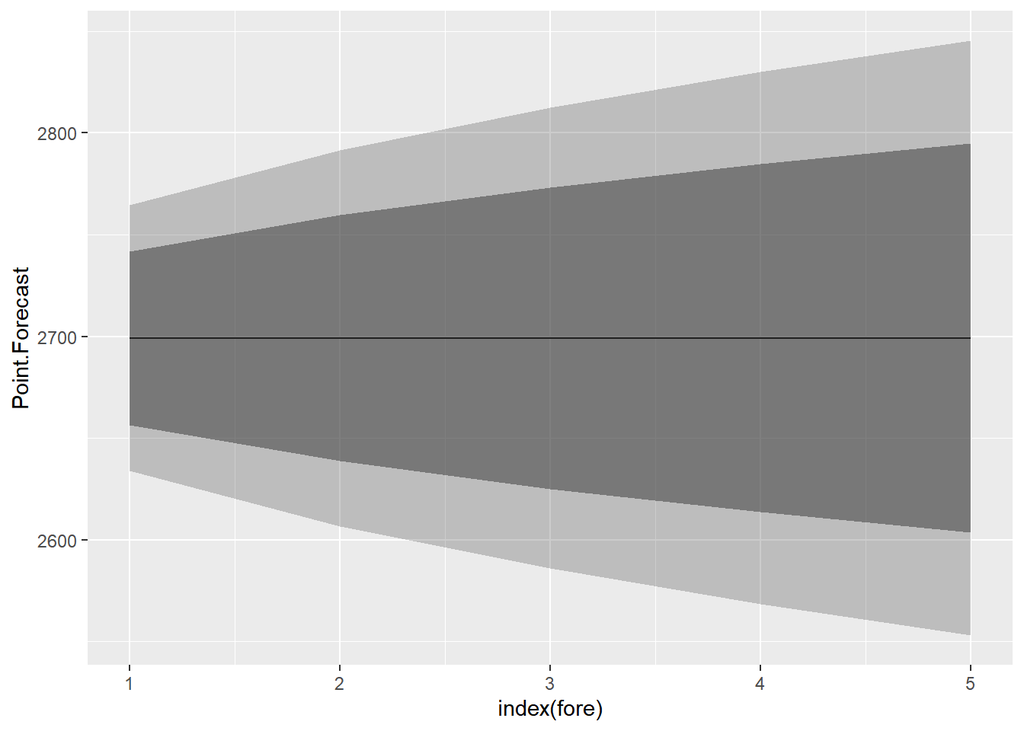

```r
ggplot(fore, aes(x = index(fore), y = Point.Forecast)) +
  geom_line() +
  geom_ribbon(aes(ymin = Lo.95, ymax = Hi.95), alpha = 0.25) +
  geom_ribbon(aes(ymin = Lo.80, ymax = Hi.80), alpha = 0.5)
```